# Teoria Macroeconômica II - Artigo parte II - Primeiro Var

Aishameriane Schmidt

5 de janeiro de 2018

# Introdução

Este documento contém a primeira especificação do VAR que eu testei.

Para fazer o BVar utilizei o pacote [`bvarsv`](https://cran.r-project.org/web/packages/bvarsv/index.html) do [Fabian Kruger](https://sites.google.com/site/fk83research/papers). Em particular, esses dois arquivos me ajudaram muito: [bvarsv: An R implementation of the Primiceri (2005) model for macroeconomic time series](https://github.com/FK83/bvarsv/blob/master/bvarsv_Nov2015_website.pdf) e [Replication of figures in Del Negro and Primiceri (2015)](https://github.com/FK83/bvarsv/blob/master/bvarsv_replication.pdf).

## Download de pacotes e dependências

```r
list.of.packages <- c("ggplot2", "forecast", "BETS", "seasonal", "seasonalview", "bvarsv", "lubridate", "zoo", "stargazer", "gridExtra", "reshape2", "ggfortify", "RColorBrewer")
new.packages <- list.of.packages[!(list.of.packages %in% installed.packages()[,"Package"])]
if(length(new.packages)) install.packages(new.packages)

library(ggplot2, quietly = TRUE)
library(forecast, quietly = TRUE)
library(BETS, quietly = TRUE)
library(seasonal, quietly = TRUE)
library(seasonalview, quietly = TRUE)
library(bvarsv, quietly = TRUE)
library(lubridate, quietly = TRUE)
library(zoo, quietly = TRUE)
library(stargazer, quietly = TRUE)
library(gridExtra, quietly = TRUE)
library(reshape2, quietly = TRUE)
library(ggfortify, quietly = TRUE)
library(RColorBrewer, quietly = TRUE)
library(scales, quietly = TRUE)
```

Aisha: Caso o BETS não esteja instalado, retirar o `eval=FALSE` do chunk abaixo e rodar ele.

```r
library(devtools)
devtools::install_github("pedrocostaferreira/BETS", force= TRUE)
```

Algumas funções auxiliares:

```r
## Peguei essa função pronta
matplot2 <- function(...){
  matplot(..., type = 'l', lty = 1, lwd = 2, bty = "n", ylab = "")
}

# Essa função calcula os quantis e organiza 1 quantil, média, 3 quantil.
stat.helper <- function(z) c(mean(z), quantile(z, c(0.16, 0.84)))[c(2,1,3)]

# Paleta de cores
cbPalette <- c("#999999", "#E69F00", "#56B4E9", "#009E73", "#F0E442", "#0072B2", "#D55E00", "#CC79A7")

cols1 <- cbPalette[c(2,4,2)]
cols2 <- cbPalette[c(2,4,6)]
```

# Especificação 1: 5 variáveis, 2003-2017

## Tentativa 1

1. Razão capital-trabalho, calculada a partir das seguintes séries:
   - `Receitas tributárias - Regime de competência - Imposto de renda - Retido na fonte - Rendimento do trabalho (7620)`
   - `Receitas tributárias - Regime de competência - Imposto de renda - Retido na fonte - Rendimento do capital (7621)`

2. Taxa Selic calculada a partir da série:
   - `Taxa de juros - Selic acumulada no mês (4390)`. Passei de taxa mensal para anual usando a fórmula: $\left((1+tx/100)^12 -1\right)*100$ e passei um filtro para tirar sazonalidade, sem transformação prévia nos dados (ajuste default na função `seas` exceto no `transformation` que ficou igual a `NONE`).
3. IPCA (para inflação), utilizando a seguinte série:
   - `Índice nacional de preços ao consumidor-amplo (IPCA) (433)`. Como ele está em variação percentual mensal, foi necessário transformar para acumulado dos últimos 12 meses utilizando a fórmula:
     $$IPCA_i = \left[\left(\prod\limits_{j=i-11}^i \left(\frac{IPCA_j}{100}+1\right) \right) -1\right]*100$$
4. IBC-Br (para o PIB per capita), utilizando a seguinte série:
   - `Índice de Atividade Econômica do Banco Central (IBC-Br) - com ajuste sazonal (24364)`. Fiz a diferença da série em log, igual o câmbio.
5. Crescimento da taxa de câmbio (para *growth of the nominal effective exchange rate*). Usei a série:
   - `Taxa de câmbio - Livre - Dólar americano (venda) - Fim de período - mensal (3696)`. Como o Mumtaz disse que usou log diferença, eu calculei o log e tirei primeira diferença nessa série.

### Download dos dados

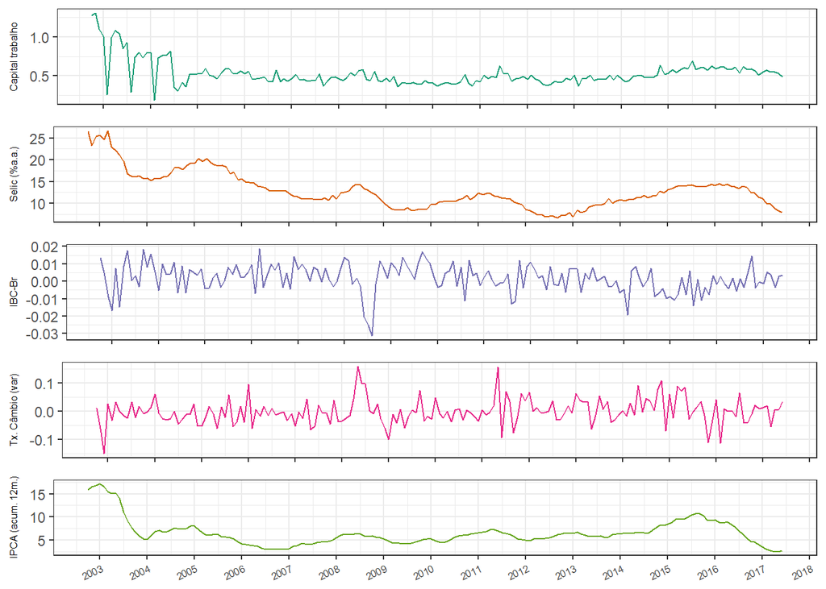

```r
#rm(list = ls())

# Auxiliary variables, so I don't need to bother when something changes
inicio <- "2003-02-01"
fim    <- "2017-10-31"

# Don't mess with this code
inicio_cambio <- paste(seq(as.Date(inicio), length = 2, by = "-1 month")[2]) # 1 mês antes do início das outras séries
inicio_ipca   <- paste(seq(as.Date(inicio), length = 12, by = "-1 month")[12]) # 12 meses antes do início das outras séries

trabalho <- BETS.get("7620", from = inicio, to = fim)
capital  <- BETS.get("7621", from = inicio, to = fim)
capital_trabalho <- capital/trabalho

# Usando ndiffs(ibcbr,test="adf",alpha = 0.1) se encontra que o ibcbr é não estacionário.
# Como todas as outras séries são estacionárias, eu vou fazer também a diferença do log, igual no câmbio
ibcbr_raw    <- BETS.get("24364", from = inicio_cambio, to = fim)
ibcbr        <- diff(log(ibcbr_raw), 1)

cambio_raw <- BETS.get("3696", from = inicio_cambio, to = fim)
cambio     <- diff(log(cambio_raw), 1)

selic_4390 <- BETS.get("4390", from = inicio, to = fim)
selic <- ((1+selic_4390/100)^(12)-1)*100

ipca_raw <- BETS.get("433", from = inicio_ipca, to = fim)
ipca_acum <- ipca_raw/100 + 1
ipca <- vector()

final <- length(ipca_acum)
for (i in 12:final){
  ipca[(i-11)] <- (prod(ipca_acum[(i-11):i])-1)*100
}

ano <- as.numeric(substr(inicio, start = 1, stop = 4))
mes <- as.numeric(substr(inicio, start = 6, stop = 7))
dia <- as.numeric(substr(inicio, start = 9, stop = 10))

ipca <- ts(ipca,  start = c(ano, mes, dia), frequency = 12) # Date format YYYY MM DD

m <- seas(x = capital_trabalho)
capital_trabalho2 <- final(m)

m <- seas(x = selic, transform.function = "none")
selic2 <- final(m)

df1 <- data.frame(seq(as.Date(inicio), length = length(ipca), by = "1 month"), capital_trabalho2, selic2, ibcbr, cambio, ipca)
names(df1) <- c("Data", "Capital_trabalho", "Selic", "IBCBr", "Cambio", "IPCA")
df2 <- melt(data = df1, id.vars = "Data")

cores <- brewer.pal(5, "Dark2")

# Gráficos individuais
p1 <- ggplot(df2[which(df2$variable == "Capital_trabalho"),], aes(Data, value, colour = variable)) +
        geom_line(alpha = 1, show.legend=F, colour = cores[1])+
        scale_y_continuous(name="Capital trabalho") +
        scale_x_date(date_breaks = "12 months")+
        theme_bw()
p1 <- p1 + theme(axis.text.x=element_blank(), axis.title.x = element_blank(), axis.title.y = element_text(size = 6))

p2 <- ggplot(df2[which(df2$variable == "Selic"),], aes(Data, value, colour = variable)) +
        geom_line(alpha = 1, show.legend=F, colour = cores[2])+
        scale_y_continuous(name="Selic (%a.a.)") +
        scale_x_date(date_breaks = "12 months")+
        theme_bw()
p2 <- p2 + theme(axis.text.x=element_blank(), axis.title.x = element_blank(), axis.title.y = element_text(size = 6))

p3 <- ggplot(df2[which(df2$variable == "IBCBr"),], aes(Data, value, colour = variable)) +
        geom_line(alpha = 1, show.legend=F, colour = cores[3])+
        scale_y_continuous(name="IBC-Br") +
        scale_x_date(date_breaks = "12 months")+
        theme_bw()
p3 <- p3 + theme(axis.text.x=element_blank(), axis.title.x = element_blank(), axis.title.y = element_text(size = 6))

p4 <- ggplot(df2[which(df2$variable == "Cambio"),], aes(Data, value, colour = variable)) +
        geom_line(alpha = 1, show.legend=F, colour = cores[4])+
        scale_y_continuous(name="Tx. Câmbio (var)") +
        scale_x_date(date_breaks = "12 months")+
        theme_bw()
p4 <- p4 + theme(axis.text.x=element_blank(), axis.title.x = element_blank(), axis.title.y = element_text(size = 6))

p5 <- ggplot(df2[which(df2$variable == "IPCA"),], aes(Data, value, colour = variable)) +
        geom_line(alpha = 1, show.legend=F, colour = cores[5])+
        scale_y_continuous(name="IPCA (acum. 12m.)") +
        scale_x_date(date_breaks = "12 months", name = "Data", labels = date_format("%Y"))+
        theme_bw()
p5 <- p5 + theme(axis.text.x = element_text(angle=25, hjust = 1, size = 6), axis.title.x = element_blank(), axis.title.y = element_text(size = 6))

grid.arrange(p1, p2, p3, p4, p5, ncol=1, nrow = 5)
```

```r
### Descriptives

descriptives     <- matrix(NA, nrow = 8, ncol = (ncol(df1)-1))
rownames(descriptives) <- c("Observações", "Mínimo", "1o quartil",
                      "Média", "Mediana",  "3o quartil", "Máximo",
                      "Desv. Pad.")

colnames(descriptives) <- names(df1)[-1]

desc <- function(x) {
  n       <- length(x)
  minimum <- min(x, na.rm = TRUE)
  first_q <- quantile(x, 0.25, na.rm = TRUE)
  media   <- mean(x, na.rm = TRUE)
  mediana <- median(x, na.rm = TRUE)
  third_q <- quantile(x, 0.75, na.rm = TRUE)
  maximum <- max(x, na.rm = TRUE)
  std     <- sd(x, na.rm = TRUE)

    return(list(n = n, minimum = minimum, first_quar = first_q, media = media, mediana = mediana, third_quar = third_q, maximum = maximum, std = std))
}

for (i in 1:8){
  descriptives[i, 1] <- round(as.numeric(desc(df1[,2])[i]),4)
  descriptives[i, 2] <- round(as.numeric(desc(df1[,3])[i]),4)
  descriptives[i, 3] <- round(as.numeric(desc(df1[,4])[i]),4)
  descriptives[i, 4] <- round(as.numeric(desc(df1[,5])[i]),4)
  descriptives[i, 5] <- round(as.numeric(desc(df1[,6])[i]),4)
}

descriptives[1,] <- as.integer(descriptives[1,])

descriptives <- data.frame(descriptives)

stargazer(descriptives, summary=FALSE, header = TRUE, type = 'html')
```

|  | Capital_trabalho | Selic | IBCBr | Cambio | IPCA |
| --- | --- | --- | --- | --- | --- |
| Observações | 177 | 177 | 177 | 177 | 177 |
| Mínimo | 0.190 | 6.707 | -0.031 | -0.149 | 2.456 |
| 1o quartil | 0.436 | 10.305 | -0.003 | -0.027 | 4.832 |
| Média | 0.526 | 12.953 | 0.002 | -0.0004 | 6.497 |
| Mediana | 0.493 | 12.263 | 0.002 | -0.005 | 6.037 |
| 3o quartil | 0.570 | 14.416 | 0.007 | 0.022 | 7.138 |
| Máximo | 1.305 | 26.608 | 0.019 | 0.158 | 17.235 |
| Desv. Pad. | 0.163 | 4.105 | 0.008 | 0.045 | 2.799 |

```r
#stargazer(descriptives, summary=FALSE, header = TRUE, type = 'latex')
```

## Ajustando um modelo BVar

Inicialmente ajustei um modelo com uma defasagem e que utiliza as primeiras 24 observações para fazer a estimativa de MQO para jogar na priori.

```r
var1 <- cbind(capital_trabalho2, selic2, ibcbr, cambio, ipca) # The bvar function does not allows data.frames

set.seed(1)

nburn. <- 5000
nrep. <- 50000

fit1 <- bvar.sv.tvp(var1, p=1, tau = 24, nburn = nburn., nrep = nrep.)
```

```
## [1] "2018-01-15 19:31:55 -- now starting MCMC"
## [1] "2018-01-15 19:33:48 -- now at iteration 5000"
## [1] "2018-01-15 19:37:41 -- now at iteration 15000"
## [1] "2018-01-15 19:41:20 -- now at iteration 25000"
## [1] "2018-01-15 19:45:11 -- now at iteration 35000"
## [1] "2018-01-15 19:49:05 -- now at iteration 45000"
## [1] "2018-01-15 19:52:48 -- now at iteration 55000"
```

## Alguns gráficos

```r
## Colocando as datas como strings
tm1 <- as.yearmon(time(var1))

# Eixo x
xax <- time(var1)
# Perde uma observação pelo lag e outras 24 pela amostra para estimar por MQO, então começa no tempo 26
xax <- xax[26:177]

# Marcas verticais
gp <- seq(1999, 2017, 1)
```

```r
# Gráfico do desvio padrão do resíduo da razão capital trabalho
sd_ct <- parameter.draws(fit1, type = "vcv", row = 1, col = 1)
```

```
## Element [1,1] of vcv matrix. Format: MCMC draws in rows, time in columns.
```

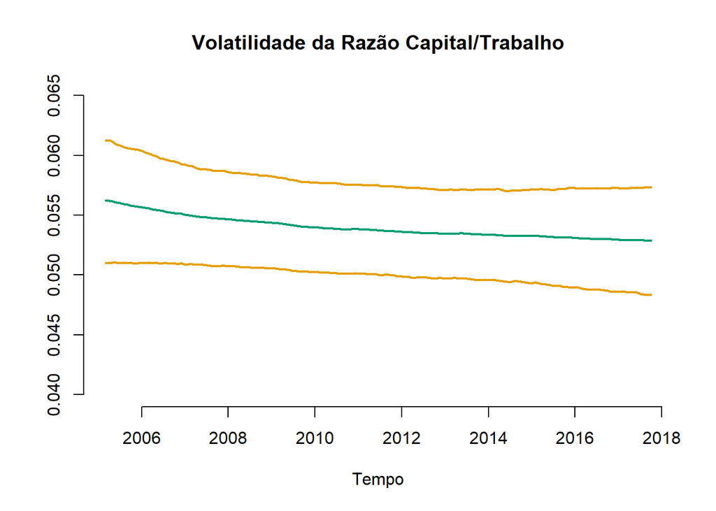

```r
x1 <- t(apply(sqrt(sd_ct), 2, stat.helper))
matplot2(x = xax, y = x1, ylim = c(0.04, 0.065), col = cols1, main = "Volatilidade da Razão Capital/Trabalho", xlab = "Tempo")
```

```r
# Gráfico do desvio padrão do resíduo da selic
sd_selic <- parameter.draws(fit1, type = "vcv", row = 2, col = 2)
```

```
## Element [2,2] of vcv matrix. Format: MCMC draws in rows, time in columns.
```

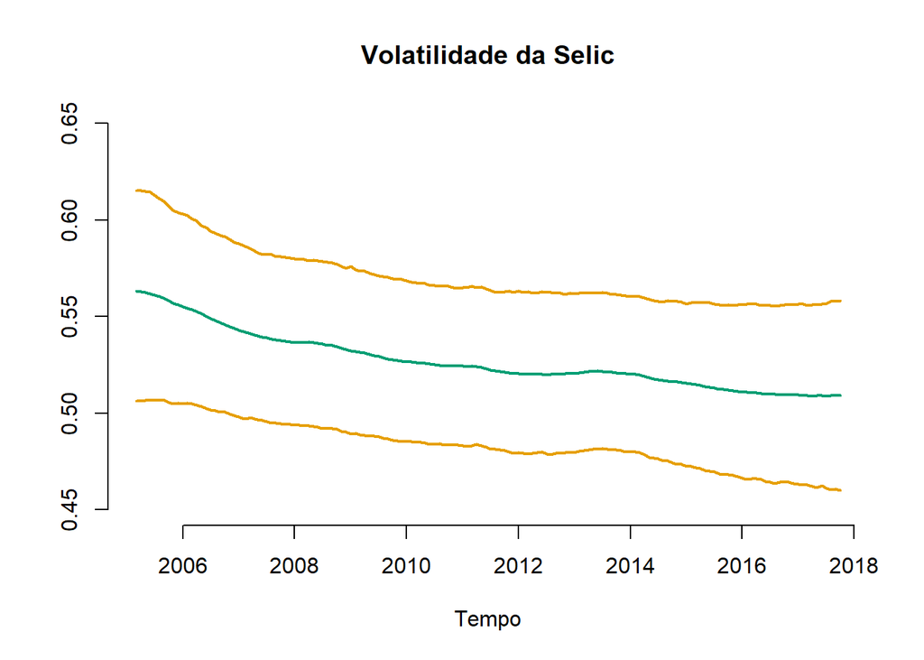

```r
x2 <- t(apply(sqrt(sd_selic), 2, stat.helper))
matplot2(x = xax, y = x2, ylim = c(0.45, 0.65), col = cols1, main = "Volatilidade da Selic", xlab = "Tempo")
```

```r
# Gráfico do desvio padrão do resíduo do ibcbr
sd_ibcbr <- parameter.draws(fit1, type = "vcv", row = 3, col = 3)
```

```
## Element [3,3] of vcv matrix. Format: MCMC draws in rows, time in columns.
```

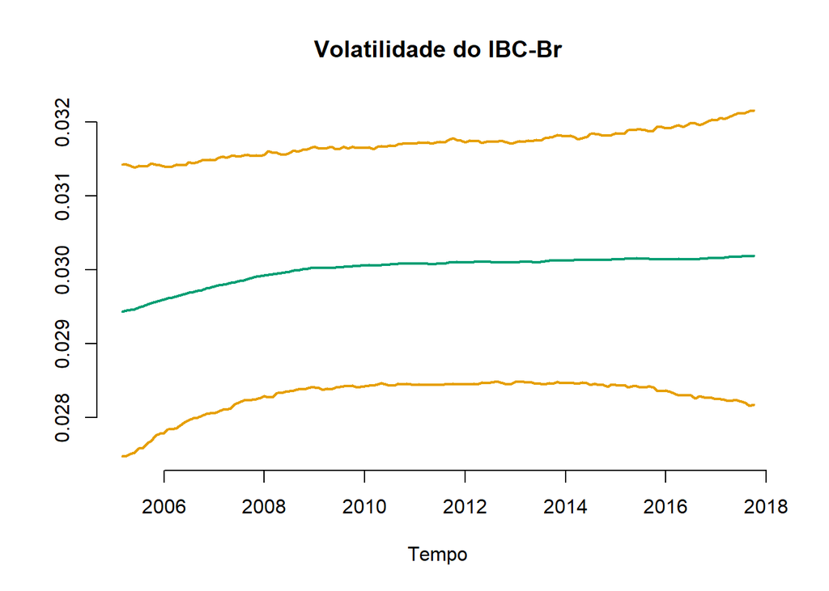

```r
x3 <- t(apply(sqrt(sd_ibcbr), 2, stat.helper))
matplot2(x = xax, y = x3, col = cols1, main = "Volatilidade do IBC-Br", xlab = "Tempo")
```

```r
# Gráfico do desvio padrão do resíduo do cambio
sd_cambio <- parameter.draws(fit1, type = "vcv", row = 4, col = 4)
```

```
## Element [4,4] of vcv matrix. Format: MCMC draws in rows, time in columns.
```

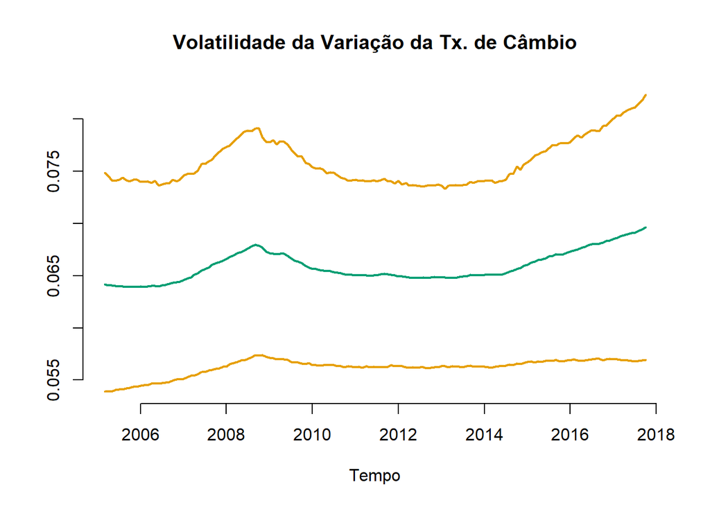

```r
x4 <- t(apply(sqrt(sd_cambio), 2, stat.helper))
matplot2(x = xax, y = x4, col = cols1, main = "Volatilidade da Variação da Tx. de Câmbio", xlab = "Tempo")
```

```r
# Gráfico do desvio padrão do resíduo do ipca
sd_ipca <- parameter.draws(fit1, type = "vcv", row = 5, col = 5)
```

```
## Element [5,5] of vcv matrix. Format: MCMC draws in rows, time in columns.
```

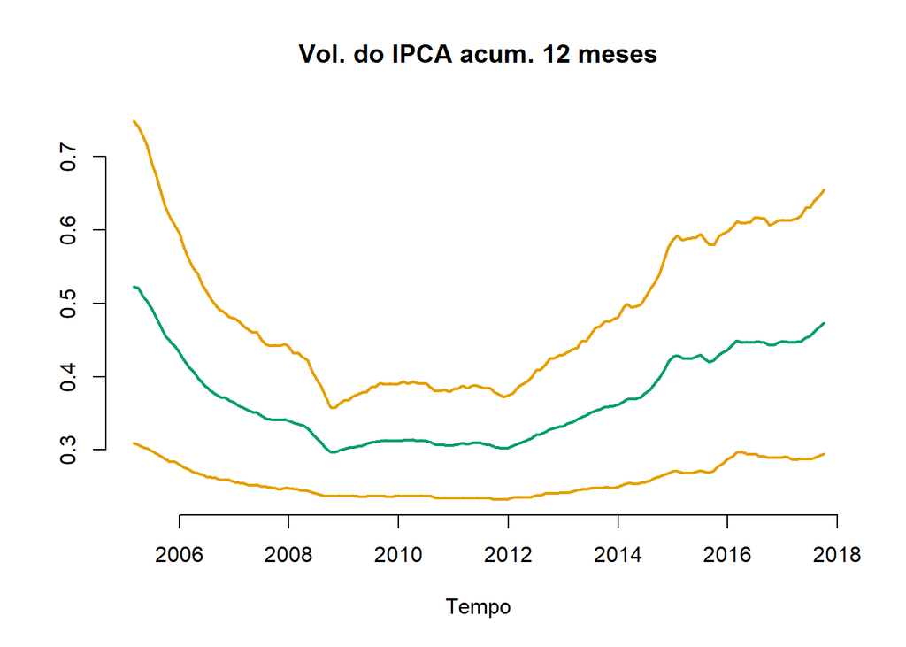

```r
x5 <- t(apply(sqrt(sd_ipca), 2, stat.helper))
matplot2(x = xax, y = x5, col = cols1, main = "Vol. do IPCA acum. 12 meses", xlab = "Tempo")
```

### Funções impulso resposta

Peguei a explicação daqui [daqui](https://github.com/FK83/bvarsv/blob/master/bvarsv_Nov2015_website.pdf): A FIR estima o impacto de um choque unitário em algum elemento de $\varepsilon_t$. Os elementos de $c_t$, $B_{j,t}$, $A_t$ e $\Sigma_t$ em (1) são mantidos fixos em seus valores em $t$. Note que a ordem das variáveis importa e deve ser justificada por argumentos econômicos. As FIR contém os percentis 5, 25, 50, 75 e 95.

```r
# Função Impulso resposta da Selic na razão capital-trabalho
ira <- impulse.responses(fit1, impulse.variable = 2, response.variable = 1)
```

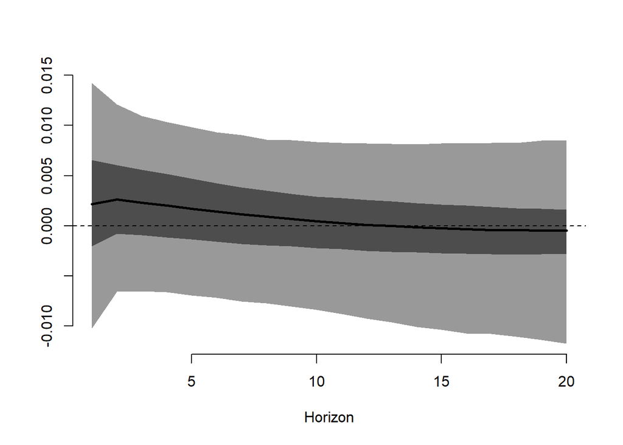

```r
# Função Impulso resposta da Selic no IBC-Br
ira <- impulse.responses(fit1, impulse.variable = 2, response.variable = 3)
```

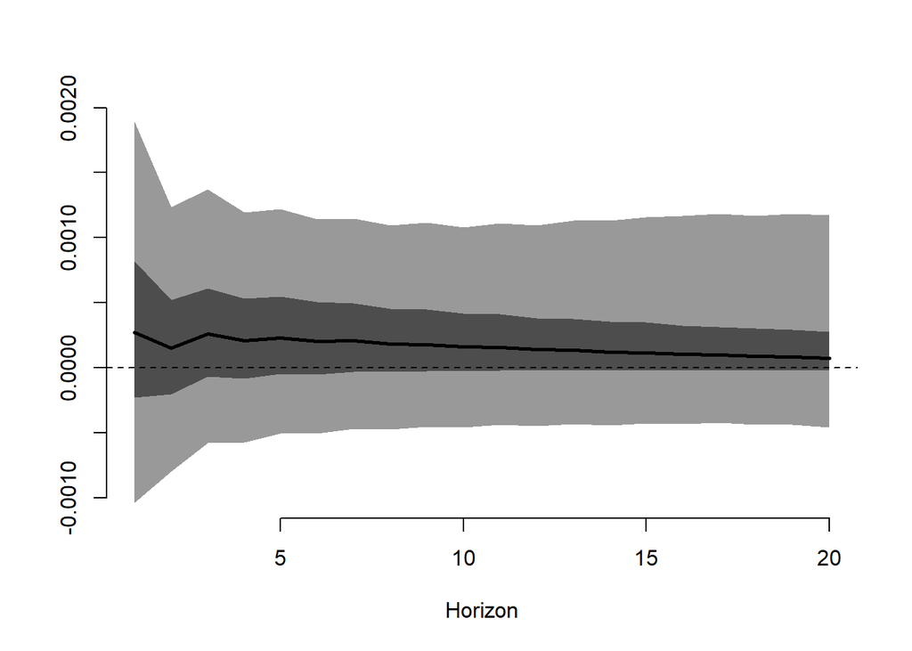

```r
# Função Impulso resposta da Selic no câmbio
ira <- impulse.responses(fit1, impulse.variable = 2, response.variable = 4)
```

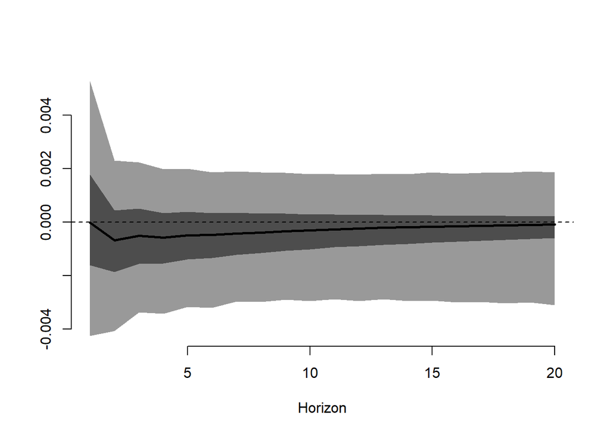

```r
# Função Impulso resposta Selic no IPCA
ira <- impulse.responses(fit1, impulse.variable = 2, response.variable = 5)
```

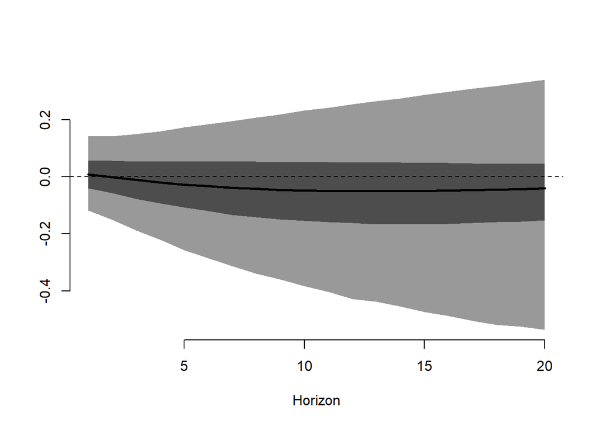

```r
# Função Impulso resposta do IBC-Br na razão capital trabalho
ira <- impulse.responses(fit1, impulse.variable = 3, response.variable = 1)
```

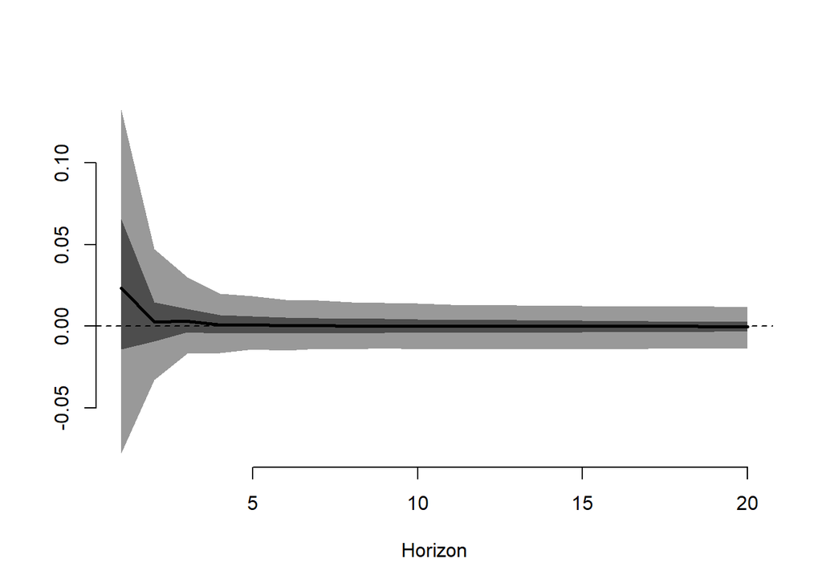

```r
# Função Impulso resposta do Cambio na razão capital trabalho
ira <- impulse.responses(fit1, impulse.variable = 4, response.variable = 1)
```

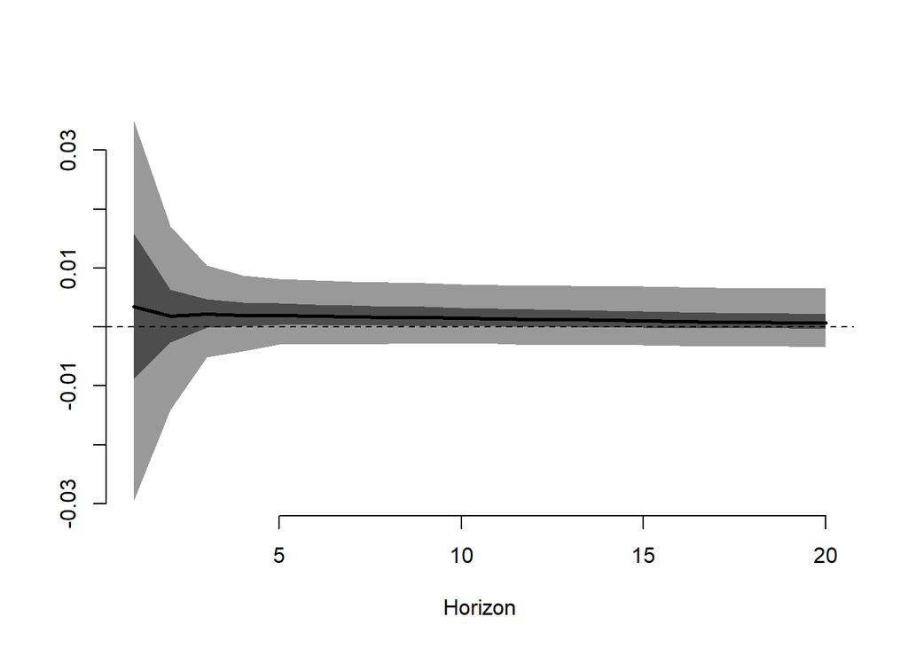

```r
# Função Impulso resposta do IPCA na razão capital trabalho
ira <- impulse.responses(fit1, impulse.variable = 5, response.variable = 1)
```

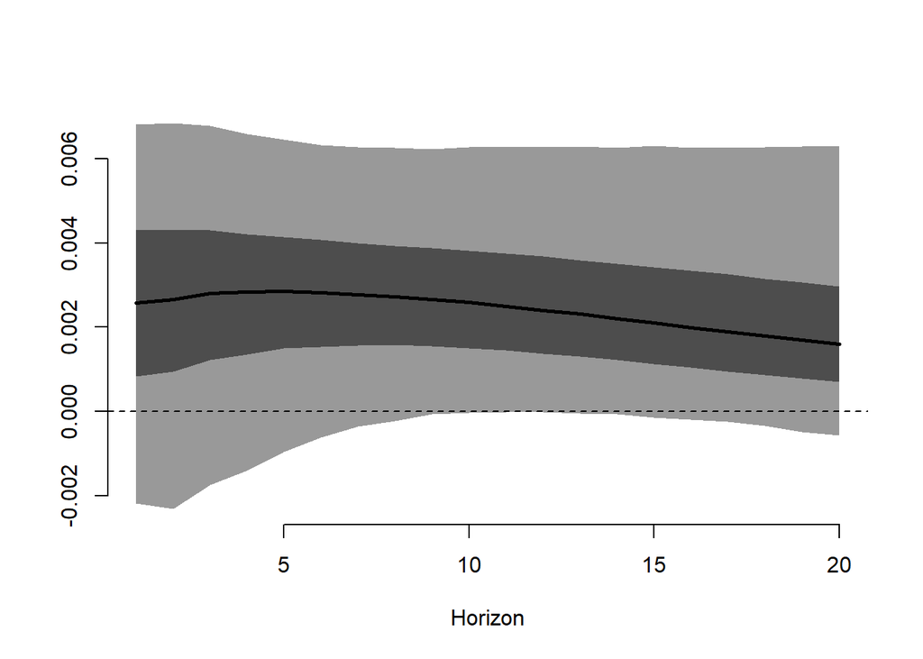